# Session 3

## Architecture - service layer

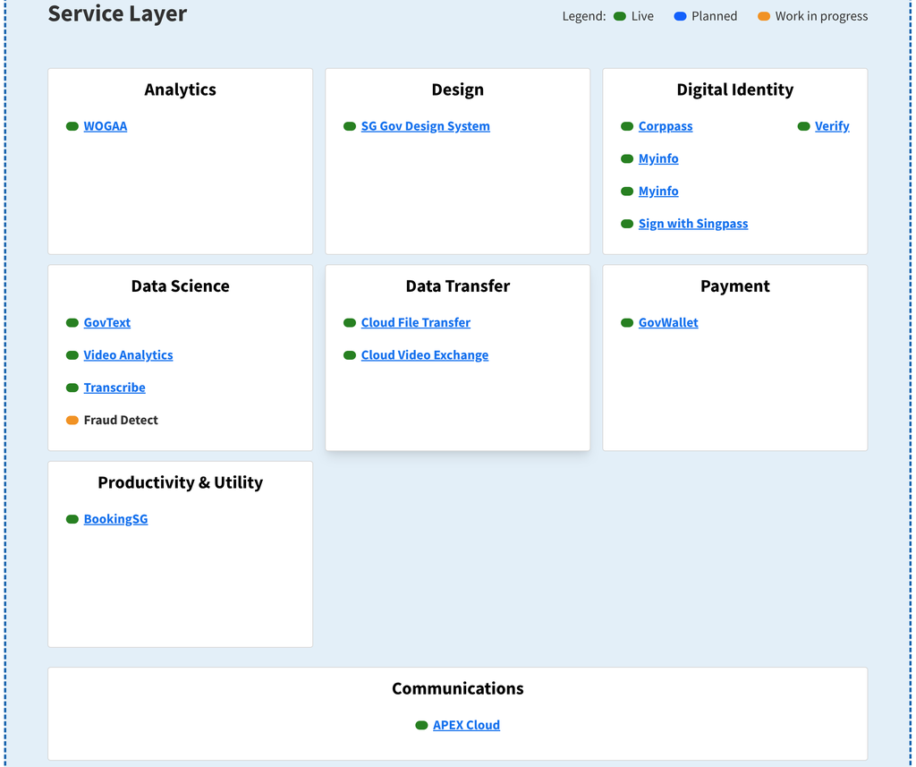

## Success story

Streamlining Payroll Submissions in Singapore: APEX’s Solution for Efficient Government Reporting

## The Problem

- Singapore-registered companies must regularly submit employee salary, workforce, and CPF contribution data to various government agencies (IRAS, MOM, CPFB).
- All required data already exists within companies’ payroll or HR systems.
- The challenge is to integrate government submissions with these systems to streamline processes, reduce manual work, and save employers time and resources.

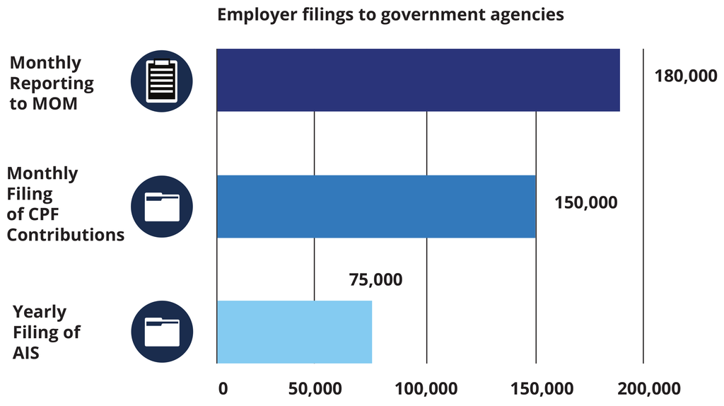

## The solution

- **APEX** unifies APIs from multiple government agencies on one secure platform.
- It enables developers, including HR and payroll software providers, to integrate easily with these services.
- APEX removes the need for manual filing reducing administrative burden and supports better compliance with payroll-related regulations.

[figure not shown]